# REGRESJA WIELORAKA - Małgorzata Milcewicz

## 1. Zbiory danych

Dane pochodzą ze strony [kaggle](https://www.kaggle.com) i dotyczą poziomu szczęścia mieszkańców różnych krajów, jak i liczby samobójstw dokonywanych w tych państwach.  
Zbiory danych:  
[kaggle-suicide](https://www.kaggle.com/russellyates88/suicide-rates-overview-1985-to-2016)  
[kaggle-happiness](https://www.kaggle.com/unsdsn/world-happiness)

## 2. Przygotowanie danych

```python
import pandas as pd

hap = pd.read_csv(r'C:\Users\Gosia\Desktop\Python\dane\2016.csv') # szczęście
su = pd.read_csv(r'C:\Users\Gosia\Desktop\Python\dane\master.csv') # samobójstwa
```

```python
#Tabela szczęście
pd.set_option("display.max_rows", 15, "display.max_columns", None)
display(hap)
```

|  | Country | Region | Happiness Rank | Happiness Score | Lower Confidence Interval | Upper Confidence Interval | Economy (GDP per Capita) | Family | Health (Life Expectancy) | Freedom | Trust (Government Corruption) | Generosity | Dystopia Residual |
| --- | --- | --- | --- | --- | --- | --- | --- | --- | --- | --- | --- | --- | --- |
| 0 | Denmark | Western Europe | 1 | 7.526 | 7.460 | 7.592 | 1.44178 | 1.16374 | 0.79504 | 0.57941 | 0.44453 | 0.36171 | 2.73939 |
| 1 | Switzerland | Western Europe | 2 | 7.509 | 7.428 | 7.590 | 1.52733 | 1.14524 | 0.86303 | 0.58557 | 0.41203 | 0.28083 | 2.69463 |
| 2 | Iceland | Western Europe | 3 | 7.501 | 7.333 | 7.669 | 1.42666 | 1.18326 | 0.86733 | 0.56624 | 0.14975 | 0.47678 | 2.83137 |
| 3 | Norway | Western Europe | 4 | 7.498 | 7.421 | 7.575 | 1.57744 | 1.12690 | 0.79579 | 0.59609 | 0.35776 | 0.37895 | 2.66465 |
| 4 | Finland | Western Europe | 5 | 7.413 | 7.351 | 7.475 | 1.40598 | 1.13464 | 0.81091 | 0.57104 | 0.41004 | 0.25492 | 2.82596 |
| ... | ... | ... | ... | ... | ... | ... | ... | ... | ... | ... | ... | ... | ... |
| 152 | Benin | Sub-Saharan Africa | 153 | 3.484 | 3.404 | 3.564 | 0.39499 | 0.10419 | 0.21028 | 0.39747 | 0.06681 | 0.20180 | 2.10812 |
| 153 | Afghanistan | Southern Asia | 154 | 3.360 | 3.288 | 3.432 | 0.38227 | 0.11037 | 0.17344 | 0.16430 | 0.07112 | 0.31268 | 2.14558 |
| 154 | Togo | Sub-Saharan Africa | 155 | 3.303 | 3.192 | 3.414 | 0.28123 | 0.00000 | 0.24811 | 0.34678 | 0.11587 | 0.17517 | 2.13540 |
| 155 | Syria | Middle East and Northern Africa | 156 | 3.069 | 2.936 | 3.202 | 0.74719 | 0.14866 | 0.62994 | 0.06912 | 0.17233 | 0.48397 | 0.81789 |
| 156 | Burundi | Sub-Saharan Africa | 157 | 2.905 | 2.732 | 3.078 | 0.06831 | 0.23442 | 0.15747 | 0.04320 | 0.09419 | 0.20290 | 2.10404 |

157 rows × 13 columns

```python
#Tabela samobójstwa
display(su)
```

|  | country | year | sex | age | suicides_no | population | suicides/100k pop | country-year | HDI for year | gdp_for_year ($) | gdp_per_capita ($) | generation |
| --- | --- | --- | --- | --- | --- | --- | --- | --- | --- | --- | --- | --- |
| 0 | Albania | 1987 | male | 15-24 years | 21 | 312900 | 6.71 | Albania1987 | NaN | 2,156,624,900 | 796 | Generation X |
| 1 | Albania | 1987 | male | 35-54 years | 16 | 308000 | 5.19 | Albania1987 | NaN | 2,156,624,900 | 796 | Silent |
| 2 | Albania | 1987 | female | 15-24 years | 14 | 289700 | 4.83 | Albania1987 | NaN | 2,156,624,900 | 796 | Generation X |
| 3 | Albania | 1987 | male | 75+ years | 1 | 21800 | 4.59 | Albania1987 | NaN | 2,156,624,900 | 796 | G.I. Generation |
| 4 | Albania | 1987 | male | 25-34 years | 9 | 274300 | 3.28 | Albania1987 | NaN | 2,156,624,900 | 796 | Boomers |
| ... | ... | ... | ... | ... | ... | ... | ... | ... | ... | ... | ... | ... |
| 27815 | Uzbekistan | 2014 | female | 35-54 years | 107 | 3620833 | 2.96 | Uzbekistan2014 | 0.675 | 63,067,077,179 | 2309 | Generation X |
| 27816 | Uzbekistan | 2014 | female | 75+ years | 9 | 348465 | 2.58 | Uzbekistan2014 | 0.675 | 63,067,077,179 | 2309 | Silent |
| 27817 | Uzbekistan | 2014 | male | 5-14 years | 60 | 2762158 | 2.17 | Uzbekistan2014 | 0.675 | 63,067,077,179 | 2309 | Generation Z |
| 27818 | Uzbekistan | 2014 | female | 5-14 years | 44 | 2631600 | 1.67 | Uzbekistan2014 | 0.675 | 63,067,077,179 | 2309 | Generation Z |
| 27819 | Uzbekistan | 2014 | female | 55-74 years | 21 | 1438935 | 1.46 | Uzbekistan2014 | 0.675 | 63,067,077,179 | 2309 | Boomers |

27820 rows × 12 columns

```python
#Zawężam dane do 2016 roku w tabeli su
su2 = su[(su['year'] == 2016 )]
display(su2)
```

|  | country | year | sex | age | suicides_no | population | suicides/100k pop | country-year | HDI for year | gdp_for_year ($) | gdp_per_capita ($) | generation |
| --- | --- | --- | --- | --- | --- | --- | --- | --- | --- | --- | --- | --- |
| 1248 | Armenia | 2016 | male | 75+ years | 12 | 61956 | 19.37 | Armenia2016 | NaN | 10,546,135,160 | 3788 | Silent |
| 1249 | Armenia | 2016 | male | 55-74 years | 16 | 237813 | 6.73 | Armenia2016 | NaN | 10,546,135,160 | 3788 | Boomers |
| 1250 | Armenia | 2016 | male | 35-54 years | 16 | 350633 | 4.56 | Armenia2016 | NaN | 10,546,135,160 | 3788 | Generation X |
| 1251 | Armenia | 2016 | male | 15-24 years | 5 | 202220 | 2.47 | Armenia2016 | NaN | 10,546,135,160 | 3788 | Millenials |
| 1252 | Armenia | 2016 | female | 75+ years | 2 | 102414 | 1.95 | Armenia2016 | NaN | 10,546,135,160 | 3788 | Silent |
| ... | ... | ... | ... | ... | ... | ... | ... | ... | ... | ... | ... | ... |
| 25307 | Thailand | 2016 | female | 75+ years | 69 | 1589015 | 4.34 | Thailand2016 | NaN | 411,755,164,833 | 6713 | Silent |
| 25308 | Thailand | 2016 | female | 55-74 years | 222 | 6049756 | 3.67 | Thailand2016 | NaN | 411,755,164,833 | 6713 | Boomers |
| 25309 | Thailand | 2016 | female | 35-54 years | 375 | 10629684 | 3.53 | Thailand2016 | NaN | 411,755,164,833 | 6713 | Generation X |
| 25310 | Thailand | 2016 | female | 25-34 years | 116 | 4702656 | 2.47 | Thailand2016 | NaN | 411,755,164,833 | 6713 | Millenials |
| 25311 | Thailand | 2016 | female | 15-24 years | 60 | 4525574 | 1.33 | Thailand2016 | NaN | 411,755,164,833 | 6713 | Millenials |

160 rows × 12 columns

```python
#Poprawiam nazwę kolumny i używam jej by połączyć obie tabele
suN = su2.rename(columns = {'country':'Country'}, inplace = False)
print('tabela samobójstw:')
print('')
print(suN.columns)
print('')
print('- - - - - - - - -')
print('tabela szczęścia:')
print('')
print(hap.columns)
```

```
tabela samobójstw:

Index(['Country', 'year', 'sex', 'age', 'suicides_no', 'population',
       'suicides/100k pop', 'country-year', 'HDI for year',
       ' gdp_for_year ($) ', 'gdp_per_capita ($)', 'generation'],
      dtype='object')

- - - - - - - - -
tabela szczęścia:

Index(['Country', 'Region', 'Happiness Rank', 'Happiness Score',
       'Lower Confidence Interval', 'Upper Confidence Interval',
       'Economy (GDP per Capita)', 'Family', 'Health (Life Expectancy)',
       'Freedom', 'Trust (Government Corruption)', 'Generosity',
       'Dystopia Residual'],
      dtype='object')
```

```python
df = pd.merge(hap, suN, on='Country', how="inner")
df.head(5)
```

|  | Country | Region | Happiness Rank | Happiness Score | Lower Confidence Interval | Upper Confidence Interval | Economy (GDP per Capita) | Family | Health (Life Expectancy) | Freedom | Trust (Government Corruption) | Generosity | Dystopia Residual | year | sex | age | suicides_no | population | suicides/100k pop | country-year | HDI for year | gdp_for_year ($) | gdp_per_capita ($) | generation |
| --- | --- | --- | --- | --- | --- | --- | --- | --- | --- | --- | --- | --- | --- | --- | --- | --- | --- | --- | --- | --- | --- | --- | --- | --- |
| 0 | Iceland | Western Europe | 3 | 7.501 | 7.333 | 7.669 | 1.42666 | 1.18326 | 0.86733 | 0.56624 | 0.14975 | 0.47678 | 2.83137 | 2016 | male | 25-34 years | 8 | 25029 | 31.96 | Iceland2016 | NaN | 20,304,098,101 | 64708 | Millenials |
| 1 | Iceland | Western Europe | 3 | 7.501 | 7.333 | 7.669 | 1.42666 | 1.18326 | 0.86733 | 0.56624 | 0.14975 | 0.47678 | 2.83137 | 2016 | male | 55-74 years | 10 | 33247 | 30.08 | Iceland2016 | NaN | 20,304,098,101 | 64708 | Boomers |
| 2 | Iceland | Western Europe | 3 | 7.501 | 7.333 | 7.669 | 1.42666 | 1.18326 | 0.86733 | 0.56624 | 0.14975 | 0.47678 | 2.83137 | 2016 | male | 35-54 years | 11 | 44024 | 24.99 | Iceland2016 | NaN | 20,304,098,101 | 64708 | Generation X |
| 3 | Iceland | Western Europe | 3 | 7.501 | 7.333 | 7.669 | 1.42666 | 1.18326 | 0.86733 | 0.56624 | 0.14975 | 0.47678 | 2.83137 | 2016 | male | 15-24 years | 6 | 24099 | 24.90 | Iceland2016 | NaN | 20,304,098,101 | 64708 | Millenials |
| 4 | Iceland | Western Europe | 3 | 7.501 | 7.333 | 7.669 | 1.42666 | 1.18326 | 0.86733 | 0.56624 | 0.14975 | 0.47678 | 2.83137 | 2016 | male | 75+ years | 1 | 8723 | 11.46 | Iceland2016 | NaN | 20,304,098,101 | 64708 | Silent |

```python
#Sprawdzam ilość wierszy dla każdego kraju
df.groupby('Country').size()
```

```
Country
Armenia           10
Austria           10
Croatia           10
Cyprus            10
Czech Republic    10
Hungary           10
Iceland           10
Lithuania         10
Mauritius         10
Mongolia          10
Netherlands       10
Qatar             10
Romania           10
Sweden            10
Thailand          10
dtype: int64
```

```python
#Tworzę nową zmienną - zbiorczą ilość samobójstw dla danego kraju dla wszystkich grup wiekowych i płci
df['suicide_avg/100k'] = df['suicides/100k pop'].groupby(df['Country']).transform('sum')/10
df.head(11)
```

|  | Country | Region | Happiness Rank | Happiness Score | Lower Confidence Interval | Upper Confidence Interval | Economy (GDP per Capita) | Family | Health (Life Expectancy) | Freedom | Trust (Government Corruption) | Generosity | Dystopia Residual | year | sex | age | suicides_no | population | suicides/100k pop | country-year | HDI for year | gdp_for_year ($) | gdp_per_capita ($) | generation | suicide_avg/100k |
| --- | --- | --- | --- | --- | --- | --- | --- | --- | --- | --- | --- | --- | --- | --- | --- | --- | --- | --- | --- | --- | --- | --- | --- | --- | --- |
| 0 | Iceland | Western Europe | 3 | 7.501 | 7.333 | 7.669 | 1.42666 | 1.18326 | 0.86733 | 0.56624 | 0.14975 | 0.47678 | 2.83137 | 2016 | male | 25-34 years | 8 | 25029 | 31.96 | Iceland2016 | NaN | 20,304,098,101 | 64708 | Millenials | 13.807 |
| 1 | Iceland | Western Europe | 3 | 7.501 | 7.333 | 7.669 | 1.42666 | 1.18326 | 0.86733 | 0.56624 | 0.14975 | 0.47678 | 2.83137 | 2016 | male | 55-74 years | 10 | 33247 | 30.08 | Iceland2016 | NaN | 20,304,098,101 | 64708 | Boomers | 13.807 |
| 2 | Iceland | Western Europe | 3 | 7.501 | 7.333 | 7.669 | 1.42666 | 1.18326 | 0.86733 | 0.56624 | 0.14975 | 0.47678 | 2.83137 | 2016 | male | 35-54 years | 11 | 44024 | 24.99 | Iceland2016 | NaN | 20,304,098,101 | 64708 | Generation X | 13.807 |
| 3 | Iceland | Western Europe | 3 | 7.501 | 7.333 | 7.669 | 1.42666 | 1.18326 | 0.86733 | 0.56624 | 0.14975 | 0.47678 | 2.83137 | 2016 | male | 15-24 years | 6 | 24099 | 24.90 | Iceland2016 | NaN | 20,304,098,101 | 64708 | Millenials | 13.807 |
| 4 | Iceland | Western Europe | 3 | 7.501 | 7.333 | 7.669 | 1.42666 | 1.18326 | 0.86733 | 0.56624 | 0.14975 | 0.47678 | 2.83137 | 2016 | male | 75+ years | 1 | 8723 | 11.46 | Iceland2016 | NaN | 20,304,098,101 | 64708 | Silent | 13.807 |
| 5 | Iceland | Western Europe | 3 | 7.501 | 7.333 | 7.669 | 1.42666 | 1.18326 | 0.86733 | 0.56624 | 0.14975 | 0.47678 | 2.83137 | 2016 | female | 25-34 years | 2 | 23233 | 8.61 | Iceland2016 | NaN | 20,304,098,101 | 64708 | Millenials | 13.807 |
| 6 | Iceland | Western Europe | 3 | 7.501 | 7.333 | 7.669 | 1.42666 | 1.18326 | 0.86733 | 0.56624 | 0.14975 | 0.47678 | 2.83137 | 2016 | female | 55-74 years | 2 | 32963 | 6.07 | Iceland2016 | NaN | 20,304,098,101 | 64708 | Boomers | 13.807 |
| 7 | Iceland | Western Europe | 3 | 7.501 | 7.333 | 7.669 | 1.42666 | 1.18326 | 0.86733 | 0.56624 | 0.14975 | 0.47678 | 2.83137 | 2016 | female | 15-24 years | 0 | 22971 | 0.00 | Iceland2016 | NaN | 20,304,098,101 | 64708 | Millenials | 13.807 |
| 8 | Iceland | Western Europe | 3 | 7.501 | 7.333 | 7.669 | 1.42666 | 1.18326 | 0.86733 | 0.56624 | 0.14975 | 0.47678 | 2.83137 | 2016 | female | 35-54 years | 0 | 43216 | 0.00 | Iceland2016 | NaN | 20,304,098,101 | 64708 | Generation X | 13.807 |
| 9 | Iceland | Western Europe | 3 | 7.501 | 7.333 | 7.669 | 1.42666 | 1.18326 | 0.86733 | 0.56624 | 0.14975 | 0.47678 | 2.83137 | 2016 | female | 75+ years | 0 | 11268 | 0.00 | Iceland2016 | NaN | 20,304,098,101 | 64708 | Silent | 13.807 |
| 10 | Netherlands | Western Europe | 7 | 7.339 | 7.284 | 7.394 | 1.46468 | 1.02912 | 0.81231 | 0.55211 | 0.29927 | 0.47416 | 2.70749 | 2016 | male | 75+ years | 123 | 541327 | 22.72 | Netherlands2016 | NaN | 777,227,541,581 | 48108 | Silent | 12.739 |

```python
#Usuwam kolumny, które na pewno się nie przydadzą
df2 = df.drop(columns=["Region", "sex", "age", "country-year", "HDI for year", "generation", "year", "suicides_no", "population", "suicides/100k pop"])
```

```python
df2.head(5)
```

|  | Country | Happiness Rank | Happiness Score | Lower Confidence Interval | Upper Confidence Interval | Economy (GDP per Capita) | Family | Health (Life Expectancy) | Freedom | Trust (Government Corruption) | Generosity | Dystopia Residual | gdp_for_year ($) | gdp_per_capita ($) | suicide_avg/100k |
| --- | --- | --- | --- | --- | --- | --- | --- | --- | --- | --- | --- | --- | --- | --- | --- |
| 0 | Iceland | 3 | 7.501 | 7.333 | 7.669 | 1.42666 | 1.18326 | 0.86733 | 0.56624 | 0.14975 | 0.47678 | 2.83137 | 20,304,098,101 | 64708 | 13.807 |
| 1 | Iceland | 3 | 7.501 | 7.333 | 7.669 | 1.42666 | 1.18326 | 0.86733 | 0.56624 | 0.14975 | 0.47678 | 2.83137 | 20,304,098,101 | 64708 | 13.807 |
| 2 | Iceland | 3 | 7.501 | 7.333 | 7.669 | 1.42666 | 1.18326 | 0.86733 | 0.56624 | 0.14975 | 0.47678 | 2.83137 | 20,304,098,101 | 64708 | 13.807 |
| 3 | Iceland | 3 | 7.501 | 7.333 | 7.669 | 1.42666 | 1.18326 | 0.86733 | 0.56624 | 0.14975 | 0.47678 | 2.83137 | 20,304,098,101 | 64708 | 13.807 |
| 4 | Iceland | 3 | 7.501 | 7.333 | 7.669 | 1.42666 | 1.18326 | 0.86733 | 0.56624 | 0.14975 | 0.47678 | 2.83137 | 20,304,098,101 | 64708 | 13.807 |

```python
df2.sort_values("Country", inplace = True)
```

```python
#sprawdzam czy wszystko jest OK
#display(df2)
```

```python
# Usuwam duplikaty
df2.drop_duplicates(keep = 'first', inplace = True)
display(df2)
```

|  | Country | Happiness Rank | Happiness Score | Lower Confidence Interval | Upper Confidence Interval | Economy (GDP per Capita) | Family | Health (Life Expectancy) | Freedom | Trust (Government Corruption) | Generosity | Dystopia Residual | gdp_for_year ($) | gdp_per_capita ($) | suicide_avg/100k |
| --- | --- | --- | --- | --- | --- | --- | --- | --- | --- | --- | --- | --- | --- | --- | --- |
| 149 | Armenia | 121 | 4.360 | 4.266 | 4.454 | 0.86086 | 0.62477 | 0.64083 | 0.14037 | 0.03616 | 0.07793 | 1.97864 | 10,546,135,160 | 3788 | 4.056 |
| 39 | Austria | 12 | 7.119 | 7.045 | 7.193 | 1.45038 | 1.08383 | 0.80565 | 0.54355 | 0.21348 | 0.32865 | 2.69343 | 390,799,991,147 | 46976 | 18.323 |
| 118 | Croatia | 74 | 5.488 | 5.402 | 5.574 | 1.18649 | 0.60809 | 0.70524 | 0.23907 | 0.04002 | 0.18434 | 2.52462 | 51,338,524,831 | 12905 | 21.356 |
| 98 | Cyprus | 69 | 5.546 | 5.442 | 5.650 | 1.31857 | 0.70697 | 0.84880 | 0.29507 | 0.05228 | 0.27906 | 2.04497 | 20,153,871,681 | 25098 | 4.715 |
| 49 | Czech Republic | 27 | 6.596 | 6.515 | 6.677 | 1.30915 | 1.00793 | 0.76376 | 0.41418 | 0.03986 | 0.09929 | 2.96211 | 195,305,084,919 | 19505 | 16.176 |
| 120 | Hungary | 91 | 5.145 | 5.056 | 5.234 | 1.24142 | 0.93164 | 0.67608 | 0.19770 | 0.04472 | 0.09900 | 1.95473 | 125,816,640,421 | 13448 | 24.134 |
| 0 | Iceland | 3 | 7.501 | 7.333 | 7.669 | 1.42666 | 1.18326 | 0.86733 | 0.56624 | 0.14975 | 0.47678 | 2.83137 | 20,304,098,101 | 64708 | 13.807 |
| 74 | Lithuania | 60 | 5.813 | 5.734 | 5.892 | 1.26920 | 1.06411 | 0.64674 | 0.18929 | 0.01820 | 0.02025 | 2.60525 | 42,773,029,835 | 15742 | 36.172 |
| 87 | Mauritius | 66 | 5.648 | 5.507 | 5.789 | 1.14372 | 0.75695 | 0.66189 | 0.46145 | 0.05203 | 0.36951 | 2.20223 | 12,232,463,656 | 10570 | 9.930 |
| 131 | Mongolia | 101 | 4.907 | 4.838 | 4.976 | 0.98853 | 1.08983 | 0.55469 | 0.35972 | 0.03285 | 0.34539 | 1.53586 | 11,183,458,131 | 4145 | 18.439 |
| 17 | Netherlands | 7 | 7.339 | 7.284 | 7.394 | 1.46468 | 1.02912 | 0.81231 | 0.55211 | 0.29927 | 0.47416 | 2.70749 | 777,227,541,581 | 48108 | 12.739 |
| 61 | Qatar | 36 | 6.375 | 6.178 | 6.572 | 1.82427 | 0.87964 | 0.71723 | 0.56679 | 0.48049 | 0.32388 | 1.58224 | 152,451,923,077 | 62484 | 1.643 |
| 101 | Romania | 71 | 5.528 | 5.427 | 5.629 | 1.16970 | 0.72803 | 0.67602 | 0.36712 | 0.00679 | 0.12889 | 2.45184 | 187,805,922,349 | 10020 | 11.633 |
| 27 | Sweden | 10 | 7.291 | 7.227 | 7.355 | 1.45181 | 1.08764 | 0.83121 | 0.58218 | 0.40867 | 0.38254 | 2.54734 | 514,459,972,806 | 55594 | 13.884 |
| 51 | Thailand | 33 | 6.474 | 6.396 | 6.552 | 1.08930 | 1.04477 | 0.64915 | 0.49553 | 0.02833 | 0.58696 | 2.57960 | 411,755,164,833 | 6713 | 7.732 |

```python
#Upewniam się czy dataframe rzeczywiście jest tak mały :D
df2.shape
```

```
(15, 15)
```

## 3. Analiza Danych

### **I. Jakie jest 5 krajów o najmniejszym/największym poziomie szczęścia (Happiness Score)?**

```python
df2.sort_values(["Happiness Score"], ascending=False).head(5)
```

|  | Country | Happiness Rank | Happiness Score | Lower Confidence Interval | Upper Confidence Interval | Economy (GDP per Capita) | Family | Health (Life Expectancy) | Freedom | Trust (Government Corruption) | Generosity | Dystopia Residual | gdp_for_year ($) | gdp_per_capita ($) | suicide_avg/100k |
| --- | --- | --- | --- | --- | --- | --- | --- | --- | --- | --- | --- | --- | --- | --- | --- |
| 0 | Iceland | 3 | 7.501 | 7.333 | 7.669 | 1.42666 | 1.18326 | 0.86733 | 0.56624 | 0.14975 | 0.47678 | 2.83137 | 20,304,098,101 | 64708 | 13.807 |
| 17 | Netherlands | 7 | 7.339 | 7.284 | 7.394 | 1.46468 | 1.02912 | 0.81231 | 0.55211 | 0.29927 | 0.47416 | 2.70749 | 777,227,541,581 | 48108 | 12.739 |
| 27 | Sweden | 10 | 7.291 | 7.227 | 7.355 | 1.45181 | 1.08764 | 0.83121 | 0.58218 | 0.40867 | 0.38254 | 2.54734 | 514,459,972,806 | 55594 | 13.884 |
| 39 | Austria | 12 | 7.119 | 7.045 | 7.193 | 1.45038 | 1.08383 | 0.80565 | 0.54355 | 0.21348 | 0.32865 | 2.69343 | 390,799,991,147 | 46976 | 18.323 |
| 49 | Czech Republic | 27 | 6.596 | 6.515 | 6.677 | 1.30915 | 1.00793 | 0.76376 | 0.41418 | 0.03986 | 0.09929 | 2.96211 | 195,305,084,919 | 19505 | 16.176 |

**Kraje o największym poziomie szczęścia to:**

1. Islandia
2. Holandia
3. Szwecja
4. Austria
5. Czechy  
   **UWAGA**!  
   Zupełnie inne wartości wychodzą, jeśli przeanalizuje się samą tabelę dotyczacą szczęścia (tutaj: **hap**). Wówczas wystarczyłoby zczytać Happiness Rank od 1 do 5 i podać odpowiednie kraje. Różnice w TOP 5 wynikają ze sposobu, w jaki połączyłam obie tabele **hap i su**. Część krajów (w tym z TOP 5 happiness) nie ma odpowiednich danych z 2016 roku dla samobójstw (np. Dania z TOP 5 w tabeli hap). Skoro ostatnim krokiem jest wyliczenie regresji wielorakiej, której zmienną objaśnianą jest zmienna samobójstw, a zmienne objaśniające znajdują się w tabeli hap, to postanowiłam, że złącze te tabele metodą inner join, żeby każdy nowopostały wiersz miał pełne informacje.

```python
df2.sort_values(["Happiness Score"], ascending=True).head(5)
```

|  | Country | Happiness Rank | Happiness Score | Lower Confidence Interval | Upper Confidence Interval | Economy (GDP per Capita) | Family | Health (Life Expectancy) | Freedom | Trust (Government Corruption) | Generosity | Dystopia Residual | gdp_for_year ($) | gdp_per_capita ($) | suicide_avg/100k |
| --- | --- | --- | --- | --- | --- | --- | --- | --- | --- | --- | --- | --- | --- | --- | --- |
| 149 | Armenia | 121 | 4.360 | 4.266 | 4.454 | 0.86086 | 0.62477 | 0.64083 | 0.14037 | 0.03616 | 0.07793 | 1.97864 | 10,546,135,160 | 3788 | 4.056 |
| 131 | Mongolia | 101 | 4.907 | 4.838 | 4.976 | 0.98853 | 1.08983 | 0.55469 | 0.35972 | 0.03285 | 0.34539 | 1.53586 | 11,183,458,131 | 4145 | 18.439 |
| 120 | Hungary | 91 | 5.145 | 5.056 | 5.234 | 1.24142 | 0.93164 | 0.67608 | 0.19770 | 0.04472 | 0.09900 | 1.95473 | 125,816,640,421 | 13448 | 24.134 |
| 118 | Croatia | 74 | 5.488 | 5.402 | 5.574 | 1.18649 | 0.60809 | 0.70524 | 0.23907 | 0.04002 | 0.18434 | 2.52462 | 51,338,524,831 | 12905 | 21.356 |
| 101 | Romania | 71 | 5.528 | 5.427 | 5.629 | 1.16970 | 0.72803 | 0.67602 | 0.36712 | 0.00679 | 0.12889 | 2.45184 | 187,805,922,349 | 10020 | 11.633 |

**Kraje o najmniejszym poziomie szczęścia to:**

1. Armenia
2. Mongolia
3. Węgry
4. Chorwacja
5. Rumunia

### II. Jakie jest 5 krajów o najmniejszej/największej liczbie samobójstw na 100 tys. mieszkańców (łącznie, we wszystkich grupach wiekowych)?

```python
df2.sort_values(["suicide_avg/100k"], ascending=True).head(5)
```

|  | Country | Happiness Rank | Happiness Score | Lower Confidence Interval | Upper Confidence Interval | Economy (GDP per Capita) | Family | Health (Life Expectancy) | Freedom | Trust (Government Corruption) | Generosity | Dystopia Residual | gdp_for_year ($) | gdp_per_capita ($) | suicide_avg/100k |
| --- | --- | --- | --- | --- | --- | --- | --- | --- | --- | --- | --- | --- | --- | --- | --- |
| 61 | Qatar | 36 | 6.375 | 6.178 | 6.572 | 1.82427 | 0.87964 | 0.71723 | 0.56679 | 0.48049 | 0.32388 | 1.58224 | 152,451,923,077 | 62484 | 1.643 |
| 149 | Armenia | 121 | 4.360 | 4.266 | 4.454 | 0.86086 | 0.62477 | 0.64083 | 0.14037 | 0.03616 | 0.07793 | 1.97864 | 10,546,135,160 | 3788 | 4.056 |
| 98 | Cyprus | 69 | 5.546 | 5.442 | 5.650 | 1.31857 | 0.70697 | 0.84880 | 0.29507 | 0.05228 | 0.27906 | 2.04497 | 20,153,871,681 | 25098 | 4.715 |
| 51 | Thailand | 33 | 6.474 | 6.396 | 6.552 | 1.08930 | 1.04477 | 0.64915 | 0.49553 | 0.02833 | 0.58696 | 2.57960 | 411,755,164,833 | 6713 | 7.732 |
| 87 | Mauritius | 66 | 5.648 | 5.507 | 5.789 | 1.14372 | 0.75695 | 0.66189 | 0.46145 | 0.05203 | 0.36951 | 2.20223 | 12,232,463,656 | 10570 | 9.930 |

**Kraje o najmniejszym wskaźniku liczby samobójstw na 100 tys. mieszkańców, to:**

1. Katar
2. Armenia
3. Cypr
4. Tajlandia
5. Mauritius  
   Ta sama uwaga, co w przypadku najmniejszego/największego wskaźnika szczęścia.

```python
df2.sort_values(["suicide_avg/100k"], ascending=False).head(5)
```

|  | Country | Happiness Rank | Happiness Score | Lower Confidence Interval | Upper Confidence Interval | Economy (GDP per Capita) | Family | Health (Life Expectancy) | Freedom | Trust (Government Corruption) | Generosity | Dystopia Residual | gdp_for_year ($) | gdp_per_capita ($) | suicide_avg/100k |
| --- | --- | --- | --- | --- | --- | --- | --- | --- | --- | --- | --- | --- | --- | --- | --- |
| 74 | Lithuania | 60 | 5.813 | 5.734 | 5.892 | 1.26920 | 1.06411 | 0.64674 | 0.18929 | 0.01820 | 0.02025 | 2.60525 | 42,773,029,835 | 15742 | 36.172 |
| 120 | Hungary | 91 | 5.145 | 5.056 | 5.234 | 1.24142 | 0.93164 | 0.67608 | 0.19770 | 0.04472 | 0.09900 | 1.95473 | 125,816,640,421 | 13448 | 24.134 |
| 118 | Croatia | 74 | 5.488 | 5.402 | 5.574 | 1.18649 | 0.60809 | 0.70524 | 0.23907 | 0.04002 | 0.18434 | 2.52462 | 51,338,524,831 | 12905 | 21.356 |
| 131 | Mongolia | 101 | 4.907 | 4.838 | 4.976 | 0.98853 | 1.08983 | 0.55469 | 0.35972 | 0.03285 | 0.34539 | 1.53586 | 11,183,458,131 | 4145 | 18.439 |
| 39 | Austria | 12 | 7.119 | 7.045 | 7.193 | 1.45038 | 1.08383 | 0.80565 | 0.54355 | 0.21348 | 0.32865 | 2.69343 | 390,799,991,147 | 46976 | 18.323 |

**Kraje o największym wskaźniku liczby samobójstw na 100 tys. mieszkańców, to:**

1. Litwa
2. Węgry
3. Chorwacja
4. Mongolia
5. Austria

### **III. Jak wygląda zależność poziomu PKB (GDP) i liczby samobójstw?**

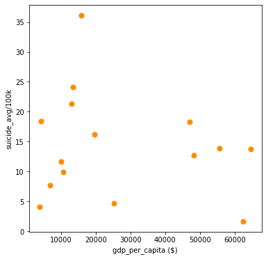

```python
ax = df2.plot.scatter(x='gdp_per_capita ($)', y='suicide_avg/100k', s=50, c='darkorange', figsize=[6,6])
```

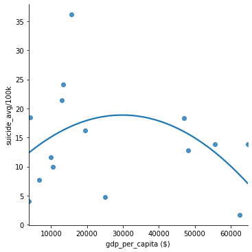

```python
import seaborn as sns
sns.lmplot(x = "gdp_per_capita ($)", y="suicide_avg/100k", data = df2, order = 2, ci = None)
```

#### Sprawdzenie korelacji między PKB per capita a liczbą samobójstw na 100 tys. mieszkańców

```python
df2['gdp_per_capita ($)'].corr(df2['suicide_avg/100k'], method='pearson')
```

```
-0.18656282668613955
```

Współczynnik korelacji wskazuje na słabą korelacje ujemną między dwoma zmiennymi.  
Nie możemy mówić o zależności między liczbą samobójstw a PKB per capita.

## 4. Prosty model regresji liniowej

Ze względu na bardzo niewielką ilość danych **(15 obserwacji)** nie dzielę zbioru na zbiór testowy i treningowy (ani walidacyjny).  
Wykonuje operacje wyłącznie na pełnym zbiorze wejściowym.

```python
from statsmodels.formula.api import ols
```

```python
print(df2.columns)
```

```
Index(['Country', 'Happiness Rank', 'Happiness Score',
       'Lower Confidence Interval', 'Upper Confidence Interval',
       'Economy (GDP per Capita)', 'Family', 'Health (Life Expectancy)',
       'Freedom', 'Trust (Government Corruption)', 'Generosity',
       'Dystopia Residual', ' gdp_for_year ($) ', 'gdp_per_capita ($)',
       'suicide_avg/100k'],
      dtype='object')
```

```python
#Zmieniam nazwy kolumn, by łatwiej było utworzyć równanie w regresji
df3 = df2.rename(columns={'Happiness Rank': 'HappinessRank', 'Economy (GDP per Capita)': 'Economy', 'Health (Life Expectancy)': "Health",
                    'Trust (Government Corruption)': 'Trust', 'suicide_avg/100k': 'Suicides'}, inplace=False)
df3.head(3)
```

|  | Country | HappinessRank | Happiness Score | Lower Confidence Interval | Upper Confidence Interval | Economy | Family | Health | Freedom | Trust | Generosity | Dystopia Residual | gdp_for_year ($) | gdp_per_capita ($) | Suicides |
| --- | --- | --- | --- | --- | --- | --- | --- | --- | --- | --- | --- | --- | --- | --- | --- |
| 149 | Armenia | 121 | 4.360 | 4.266 | 4.454 | 0.86086 | 0.62477 | 0.64083 | 0.14037 | 0.03616 | 0.07793 | 1.97864 | 10,546,135,160 | 3788 | 4.056 |
| 39 | Austria | 12 | 7.119 | 7.045 | 7.193 | 1.45038 | 1.08383 | 0.80565 | 0.54355 | 0.21348 | 0.32865 | 2.69343 | 390,799,991,147 | 46976 | 18.323 |
| 118 | Croatia | 74 | 5.488 | 5.402 | 5.574 | 1.18649 | 0.60809 | 0.70524 | 0.23907 | 0.04002 | 0.18434 | 2.52462 | 51,338,524,831 | 12905 | 21.356 |

```python
#Sprawdzam czy wszystkie zmienne są zmiennymi ciągłymi
#df3.dtypes
```

```python
#Buduję model regresji wielorakiej na podstawie zadanych zmiennych objaśniających
model = ols('Suicides ~ Economy + Family + Health + Freedom + Trust', data=df3).fit()
print(model.summary())
```

```
                            OLS Regression Results
==============================================================================
Dep. Variable:               Suicides   R-squared:                       0.624
Model:                            OLS   Adj. R-squared:                  0.415
Method:                 Least Squares   F-statistic:                     2.983
Date:                Wed, 03 Nov 2021   Prob (F-statistic):             0.0735
Time:                        13:30:23   Log-Likelihood:                -46.106
No. Observations:                  15   AIC:                             104.2
Df Residuals:                       9   BIC:                             108.5
Df Model:                           5
Covariance Type:            nonrobust
==============================================================================
                 coef    std err          t      P>|t|      [0.025      0.975]
------------------------------------------------------------------------------
Intercept    -14.1931     19.220     -0.738      0.479     -57.672      29.285
Economy       18.3549     15.406      1.191      0.264     -16.496      53.206
Family        34.8005     11.595      3.001      0.015       8.571      61.030
Health        -9.1976     26.055     -0.353      0.732     -68.138      49.742
Freedom      -44.9562     19.186     -2.343      0.044     -88.359      -1.553
Trust        -19.7543     22.832     -0.865      0.409     -71.404      31.896
==============================================================================
Omnibus:                        0.598   Durbin-Watson:                   2.282
Prob(Omnibus):                  0.741   Jarque-Bera (JB):                0.612
Skew:                           0.199   Prob(JB):                        0.736
Kurtosis:                       2.094   Cond. No.                         36.3
==============================================================================

Notes:
[1] Standard Errors assume that the covariance matrix of the errors is correctly specified.
```

Maksymalne przeskalowane R-kwadrat wskazuje, że **41,5%** zmiennej Suicides zostało wyjaśnionych przez model.

Równanie regresji wielorakiej:  
**y = -14.1931 + 18.3549 * Economy + 34.8005 * Family - 9.1976 * Health - 44.9562 * Freedom - 19.7543 * Trust**

```python
#Przepisuje ręcznie równanie, bo z jakiegoś powodu kod poniżej się uruchamia, ale liczy coś w nieskończoność... :)
df3['Predict_Suicides'] = -14.1931 + 18.3549 * df3['Economy'] + 34.8005 * df3['Family'] - 9.1976 * df3['Health'] - 44.9562 * df3['Freedom'] - 19.7543 * df3['Trust']
df3.head(5)
```

|  | Country | HappinessRank | Happiness Score | Lower Confidence Interval | Upper Confidence Interval | Economy | Family | Health | Freedom | Trust | Generosity | Dystopia Residual | gdp_for_year ($) | gdp_per_capita ($) | Suicides | Predict_Suicides |
| --- | --- | --- | --- | --- | --- | --- | --- | --- | --- | --- | --- | --- | --- | --- | --- | --- |
| 149 | Armenia | 121 | 4.360 | 4.266 | 4.454 | 0.86086 | 0.62477 | 0.64083 | 0.14037 | 0.03616 | 0.07793 | 1.97864 | 10,546,135,160 | 3788 | 4.056 | 10.431292 |
| 39 | Austria | 12 | 7.119 | 7.045 | 7.193 | 1.45038 | 1.08383 | 0.80565 | 0.54355 | 0.21348 | 0.32865 | 2.69343 | 390,799,991,147 | 46976 | 18.323 | 14.083169 |
| 118 | Croatia | 74 | 5.488 | 5.402 | 5.574 | 1.18649 | 0.60809 | 0.70524 | 0.23907 | 0.04002 | 0.18434 | 2.52462 | 51,338,524,831 | 12905 | 21.356 | 10.721880 |
| 98 | Cyprus | 69 | 5.546 | 5.442 | 5.650 | 1.31857 | 0.70697 | 0.84880 | 0.29507 | 0.05228 | 0.27906 | 2.04497 | 20,153,871,681 | 25098 | 4.715 | 12.507126 |
| 49 | Czech Republic | 27 | 6.596 | 6.515 | 6.677 | 1.30915 | 1.00793 | 0.76376 | 0.41418 | 0.03986 | 0.09929 | 2.96211 | 195,305,084,919 | 19505 | 16.176 | 18.480561 |

```python
#predictors = ['Economy', 'Family', 'Health', 'Freedom', 'Trust']
#outcome_pred = model.predict(predictors)
```

```python
#Tabela do porównania prawdziwych wyników z prognozami
compare = pd.DataFrame({'Country': df3['Country'], 'Actual Suicides': df3['Suicides'], 'Predicted Suicides': df3['Predict_Suicides']})
compare
```

|  | Country | Actual Suicides | Predicted Suicides |
| --- | --- | --- | --- |
| 149 | Armenia | 4.056 | 10.431292 |
| 39 | Austria | 18.323 | 14.083169 |
| 118 | Croatia | 21.356 | 10.721880 |
| 98 | Cyprus | 4.715 | 12.507126 |
| 49 | Czech Republic | 16.176 | 18.480561 |
| 120 | Hungary | 24.134 | 25.025011 |
| 0 | Iceland | 13.807 | 16.779582 |
| 74 | Lithuania | 36.172 | 31.316756 |
| 87 | Mauritius | 9.930 | 5.281351 |
| 131 | Mongolia | 18.439 | 19.955508 |
| 17 | Netherlands | 12.739 | 10.300906 |
| 61 | Qatar | 1.643 | 8.333842 |
| 101 | Romania | 11.633 | 9.756221 |
| 27 | Sweden | 13.884 | 8.414416 |
| 51 | Thailand | 7.732 | 13.352004 |

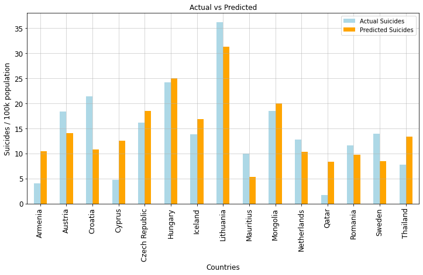

```python
#Wykres wartości rzeczywistych w porównaniu z prognozowanymi
import matplotlib.pyplot as plt
data = compare.head(25)
data.plot(x="Country", kind='bar',figsize=(12,6), fontsize=12, color=['lightblue', 'orange'])
plt.grid(which='major', linewidth='0.5')
plt.grid(which='minor', linewidth='0.5')
plt.title('Actual vs Predicted', fontsize=12)
plt.xlabel("Countries", fontsize=12)
plt.ylabel("Suicides / 100k population", fontsize=12)
plt.show()
```

Na podstawie wcześniejszych statystyk i powyższego zestawienia oraz wykresu możemy stwierdzić, że taki model słabo odwzorowuje rzeczywistość i nie mógłby zostać użyty w prawdziwym życiu. Zmienne Economy, Family, Health, Freedom i Trust nie opisują dobrze zmiennej objaśnianej.